# SAVI case study — STING signature on monocytic reference

Posterior models, compression, and merge with SAVI pseudobulk

Author

Affiliation

Chen Zhan

SAiGENCI, The University of Adelaide

Published

29 May 2026

Abstract

This notebook applies the same pattern as the Wu breast cancer PAM50 toy model: we take a literature-defined gene set from a published SAVI PBMC study, align it to Ensembl gene ids present in the posterior HCA monocytic `targets` store, optionally re-fit and compress `brms` models with `poco`, then load SAVI pseudobulk (GEO) and healthy reference samples for downstream comparison of observed counts to reference posteriors.

# Introduction

[STING](https://en.wikipedia.org/wiki/Stimulator_of_interferon_genes)-associated vasculopathy with onset in infancy (**SAVI**) is caused by gain-of-function mutations in *STING1*. De Cevins *et al.* performed single-cell RNA-seq of PBMCs from SAVI patients and healthy controls, and an IFN-β time-course in healthy PBMCs, to dissect IFN-dependent and IFN-independent programmes. They highlight disease-associated monocytes and propose a **21-gene** transcriptomic signature of STING activation that is **enriched for TNF-α / NF-κB–related biology** and **filtered against IFN-β–induced genes** in monocytes and DCs (Figure 6; Table S6).

**Primary publication (open access):** de Cevins, C., *et al.* (2023). Single-cell RNA-sequencing of PBMCs from SAVI patients reveals disease-associated monocytes with elevated integrated stress response. *Cell Reports Medicine* **4**, 101333. https://doi.org/10.1016/j.xcrm.2023.101333 — PMC: https://pmc.ncbi.nlm.nih.gov/articles/PMC10772457/.

**Data:** scRNA-seq are deposited under superseries GSE226601: SAVI cohort GSE226598, IFN-β dataset GSE226572. Pseudobulk for this notebook is prepared in `dev/SAVI/data/prepare_data.R` from the GEO Seurat object.

**Scope of this document:** We do **not** reproduce the paper’s within-study differential analysis or IFN-β filtering steps here. We use their **published 21-gene symbol list** (Table S6 / Figure 6) as biomarkers, fit or load **monocytic-lineage** reference models from the lab `targets` store, and attach **SAVI sample × cell type** pseudobulk plus **`offset == 0`** reference samples for planned comparisons to healthy baselines (same structural role as `pam50_toy_model.qmd` for breast cancer).

# Library setup

```r
# HPC / project R library (adjust if running elsewhere)
.libPaths("/hpcfs/users/a1237163/R/x86_64-pc-linux-gnu-library/4.5")

library(tibble)
library(tidyr)
library(dplyr)
library(tidySummarizedExperiment)
library(SummarizedExperiment)
library(S4Vectors)
library(AnnotationDbi)
library(org.Hs.eg.db)
library(tidybulk)
library(glue)
library(purrr)
library(furrr)
library(future)
library(lobstr)
library(posterior)
library(progressr)
library(brms)
library(poco)
library(tidyverse)
library(ggplot2)
library(forcats)
library(patchwork)
library(pheatmap)
library(RColorBrewer)
library(targets)
library(stringr)
library(Seurat)
library(tidyseurat)
```

# STING activation signature (21 genes)

The symbols below follow **Table S6** / Figure 6 in de Cevins *et al.* (2023). We map HGNC symbols to Ensembl via `org.Hs.eg.db` for overlap with the reference model feature space; **lncRNAs and some readthrough ids** may return `NA` here even when present in the single-cell count matrix — those rows are dropped from the `targets`-based extraction unless you supply Ensembl ids manually.

```r
sting_signature_21 <- tibble(
  gene = c(
    "AC253572.2",
    "ADRB2",
    "ANKRD28",
    "ANXA1",
    "AQP9",
    "AZIN1-AS1",
    "IL1B",
    "JARID2",
    "KLF4",
    "MIR4435-2HG",
    "OTUD1",
    "PLAUR",
    "PTGS2",
    "PTX3",
    "SELENOK",
    "TGIF1",
    "TREM1",
    "TSC22D2",
    "ZBTB43",
    "ZFP36L2",
    "ZNF503"
  )
) |>
  mutate(
    .feature = AnnotationDbi::mapIds(
      org.Hs.eg.db::org.Hs.eg.db,
      keys = gene,
      column = "ENSEMBL",
      keytype = "SYMBOL",
      multiVals = "first"
    )
  )

sting_signature_21
```

| gene | .feature |
| --- | --- |
| AC253572.2 | NA |
| ADRB2 | ENSG00000169252 |
| ANKRD28 | ENSG00000206560 |
| ANXA1 | ENSG00000135046 |
| AQP9 | ENSG00000103569 |
| AZIN1-AS1 | NA |
| IL1B | ENSG00000125538 |
| JARID2 | ENSG00000008083 |
| KLF4 | ENSG00000136826 |
| MIR4435-2HG | ENSG00000172965 |

[output cut: 11 more lines]

# Reference model store (`targets`)

Posterior HCA models live under `params$model_store_root`, in a subfolder named after the harmonised cell type (here `V1_monocytic` when `params$target_cell_type` is `"monocytic"`). Branch metadata encodes which Ensembl gene each `estimates_chunk_*` target belongs to (`Gene:___ENSG...___` in the recorded warning field).

```r
model_path <- file.path(
  params$model_store_root,
  paste0("V1_", params$target_cell_type)
)

model_meta <-
  targets::tar_meta(
    starts_with("estimates_chunk_"),
    store = file.path(model_path, "_targets")
  ) |>
  dplyr::filter(type == "branch") |>
  mutate(
    .feature = stringr::str_extract(
      warnings,
      "(?<=Gene:___)ENSG\\d+(?=___)"
    )
  )

# How many of the 21 (with successful SYMBOL→ENSEMBL map) appear in the store?
n_sig_in_store <- sum(sting_signature_21$.feature %in% model_meta$.feature, na.rm = TRUE)
n_sig_mapped <- sum(!is.na(sting_signature_21$.feature))

tibble(
  signature_genes = nrow(sting_signature_21),
  mapped_to_ensembl = n_sig_mapped,
  present_in_targets_store = n_sig_in_store
)
```

| signature_genes | mapped_to_ensembl | present_in_targets_store |
| --- | --- | --- |
| 21 | 19 | 16 |

# Fit and compress `brms` models (optional, heavy)

Set **`params$run_fits: true`** when rendering (or in the YAML) to re-run extraction, posterior correlation partitioning, `poco::compress_brmsfit`, and `saveRDS`. By default this chunk is **skipped** and the next section loads `params$estimates_rds`.

For each gene: read the precomputed `estimates_chunk` from disk (`tar_read_raw()` from the **targets** package, same usage as `dev/posteriorHCA_brms_fit_compression_test.qmd`), strip large environments from the fit, optionally compress with `poco`, and record layout / fidelity metrics.

```r
handlers(global = TRUE)
handlers("progress")

options(future.globals.maxSize = 5 * 1024^3)

n_components <- params$n_components
corr_threshold <- params$corr_threshold

extract_one_biomarker <- function(ensg) {
  estimates_chunk <-
    model_meta |>
    dplyr::filter(.feature == ensg) |>
    dplyr::pull(name) |>
    tar_read_raw(store = file.path(model_path, "_targets")) |>
    dplyr::select(-tar_group) |>
    mutate(
      gene = sting_signature_21 |>
        dplyr::filter(!is.na(.feature), .feature == ensg) |>
        dplyr::pull(gene),
      cell_type = params$target_cell_type,
      brms_fit = purrr::map(brms_fit, poco::strip_brmsfit_envs)
    )

  fit_brms <- estimates_chunk$brms_fit[[1]]

  posterior_cor <- poco::posterior_correlation(
    fit_brms,
    type = "correlation",
    method = "pearson"
  )
  original_draws <- posterior::as_draws_matrix(fit_brms)

  partition <- poco::partition_parameters_clusters(
    posterior_cor,
    threshold = corr_threshold,
    min_size = 2L,
    simple_output = FALSE
  )

  layout_tbl <- tibble(
    n_components = n_components,
    corr_threshold = corr_threshold,
    n_blocks = length(partition$blocks),
    block_size_max = if (length(partition$blocks)) max(lengths(partition$blocks)) else 0L,
    block_size_med = if (length(partition$blocks)) {
      as.integer(stats::median(lengths(partition$blocks)))
    } else {
      0L
    },
    n_remainder = length(partition$remainder)
  )

  compress_tic <- Sys.time()
  compressed_blockwise <- tryCatch(
    poco::compress_brmsfit(
      brmsfit = fit_brms,
      method = "mclust",
      n_components = n_components,
      partition = partition,
      cluster_BPPARAM = 1L,
      verbose = FALSE
    ),
    error = function(e) {
      warning(
        "compress_brmsfit failed: ",
        conditionMessage(e),
        call. = FALSE,
        immediate. = TRUE
      )
      NULL
    }
  )
  time_used <- as.numeric(difftime(Sys.time(), compress_tic, units = "secs"))

  fid_blockwise <- if (is.null(compressed_blockwise)) {
    NULL
  } else {
    tryCatch(
      poco::evaluate_compression(
        compressed_blockwise$compressed,
        original_draws,
        seed = 1L
      ),
      error = function(e) {
        warning(
          "evaluate_compression failed: ",
          conditionMessage(e),
          call. = FALSE,
          immediate. = TRUE
        )
        NULL
      }
    )
  }

  if (is.null(compressed_blockwise)) {
    layout_tbl <- layout_tbl |>
      mutate(
        compression_ok = FALSE,
        time_used = NA_real_,
        compression_rate = NA_real_,
        energy_pct = NA_real_,
        c2st_pct = NA_real_,
        reproduction_pct = NA_real_
      )
  } else {
    estimates_chunk$brms_fit_compressed <- list(compressed_blockwise)
    layout_tbl <- layout_tbl |>
      mutate(
        compression_ok = TRUE,
        time_used = time_used,
        compression_rate =
          as.numeric(lobstr::obj_size(compressed_blockwise)) /
            as.numeric(lobstr::obj_size(fit_brms))
      )
  }

  if (is.null(fid_blockwise)) {
    layout_tbl <- layout_tbl |>
      mutate(
        energy_pct = NA_real_,
        c2st_pct = NA_real_,
        reproduction_pct = NA_real_
      )
  } else {
    en <- fid_blockwise$metrics$energy$reproduction_pct
    c2 <- fid_blockwise$metrics$c2st$reproduction_pct
    layout_tbl <- layout_tbl |>
      mutate(
        energy_pct = if (is.null(en)) NA_real_ else en,
        c2st_pct = if (is.null(c2)) NA_real_ else c2,
        reproduction_pct = fid_blockwise$reproduction_pct
      )
  }

  estimates_chunk |> tibble::add_column(layout_tbl)
}

sting_signature_21 |>
  dplyr::filter(.feature %in% model_meta$.feature) |>
  dplyr::pull(.feature) -> biomarkers

with_progress({
  p <- progressr::progressor(along = biomarkers)
  sting_estimates_chunk <- purrr::map_dfr(biomarkers, function(ensg) {
    p(sprintf("Processing %s", ensg))
    extract_one_biomarker(ensg)
  })
})

saveRDS(sting_estimates_chunk, params$estimates_rds)
```

# Loaded estimates (preview)

```r
sting_estimates_chunk <- readRDS(params$estimates_rds)

sting_estimates_chunk |>
  dplyr::select(.feature, gene, compression_ok, compression_rate, reproduction_pct) |>
  head(10)
```

| .feature | gene | compression_ok | compression_rate | reproduction_pct |
| --- | --- | --- | --- | --- |
| ENSG00000169252 | ADRB2 | TRUE | 0.4843511 | 80.02750 |
| ENSG00000206560 | ANKRD28 | TRUE | 0.4787770 | 84.20969 |
| ENSG00000135046 | ANXA1 | TRUE | 0.4876678 | 80.07188 |
| ENSG00000103569 | AQP9 | TRUE | 0.4810870 | 84.81937 |
| ENSG00000125538 | IL1B | TRUE | 0.4814599 | 64.58938 |
| ENSG00000008083 | JARID2 | TRUE | 0.4835099 | 87.73281 |
| ENSG00000136826 | KLF4 | TRUE | 0.4911848 | 63.16312 |
| ENSG00000165312 | OTUD1 | TRUE | 0.4826568 | 83.37562 |
| ENSG00000011422 | PLAUR | TRUE | 0.4766429 | 77.42219 |
| ENSG00000073756 | PTGS2 | TRUE | 0.4839802 | 82.66938 |

# SAVI pseudobulk and healthy reference samples

**SAVI object:** RDS produced by `prepare_data.R` — pseudobulk counts aggregated with Seurat `AggregateExpression` by **`Sample`** and **`CellType`** (see GEO object metadata for treatment and category).

**Reference:** `pseudobulk_sample` from the same monocytic `targets` store is a `SummarizedExperiment` whose count assay is backed by the shared **Zenodo `pseudobulk_se.h5ad`** path. Rows with **`offset == 0`** are interpreted as healthy baseline samples for merge and posterior comparison (analogous to the breast epithelial reference in `pam50_toy_model.qmd`).

**Merge (same idea as `pam50_toy_model.qmd` § merge-se):** `SAVI_pseudobulk_sobj` is a **Seurat** object whose **RNA assay counts are row-named by gene symbol**. We map symbols → **Ensembl** (deduplicated), build a `SummarizedExperiment` with **`sample_role = "savi_pseudobulk"`**, then **column-bind** with reference columns after intersecting **shared Ensembl ids** and **assay names**.

```r
SAVI_pseudobulk_sobj <-
  readRDS(params$savi_pseudobulk_rds) %>%
  filter(CellType == '17. Disease-associated monocytes')

pseudobulk_sample <- targets::tar_read(
  pseudobulk_sample,
  store = file.path(model_path, "_targets")
)

# Point DelayedArray/HDF5 backend to the local h5ad-backed matrix (path may differ on HPC)
pseudobulk_sample@assays@data@listData[["counts"]]@seed@seed@seed@filepath <-
  params$pseudobulk_h5ad

ref_sample <-
  pseudobulk_sample |>
  dplyr::filter(offset == 0)

SummarizedExperiment::colData(ref_sample)$sample_role <- "reference"

# --- SAVI: Seurat counts are rownames = gene symbols (see prepare_data.R) ---
counts_sym <- as.matrix(
  tryCatch(
    SeuratObject::LayerData(SAVI_pseudobulk_sobj, assay = "RNA", layer = "counts"),
    error = function(e) {
      Seurat::GetAssayData(SAVI_pseudobulk_sobj, assay = "RNA", slot = "counts")
    }
  )
)

sym <- rownames(counts_sym)
ensg <- AnnotationDbi::mapIds(
  org.Hs.eg.db::org.Hs.eg.db,
  keys = sym,
  column = "ENSEMBL",
  keytype = "SYMBOL",
  multiVals = "first"
)
keep <- !is.na(ensg) & !duplicated(ensg)
ensg <- ensg[keep]

counts_ens <- counts_sym[keep, , drop = FALSE]
rownames(counts_ens) <- ensg

cd_savi <- as.data.frame(SAVI_pseudobulk_sobj@meta.data)
rownames(cd_savi) <- colnames(counts_ens)
cd_savi$sample_role <- "savi_pseudobulk"
cd_savi$offset <- 0L
if (!"cell_type_unified_ensemble" %in% names(cd_savi)) {
  cd_savi$cell_type_unified_ensemble <- cd_savi$CellType
}

se_savi_ensembl <- SummarizedExperiment::SummarizedExperiment(
  assays = list(counts = counts_ens),
  colData = S4Vectors::DataFrame(cd_savi, row.names = colnames(counts_ens)),
  rowData = S4Vectors::DataFrame(
    gene_symbol = sym[keep],
    row.names = ensg
  )
)

# --- rbind-like merge of SE columns (intersect genes, union colData columns) ---
merge_summarized_experiments <- function(...) {
  ses <- list(...)
  assay_names <- Reduce(intersect, lapply(ses, SummarizedExperiment::assayNames))
  if (length(assay_names) == 0L) {
    stop("No shared assays between SummarizedExperiment objects.")
  }

  genes <- Reduce(intersect, lapply(ses, rownames))
  if (length(genes) == 0L) {
    stop("No shared rownames between SummarizedExperiment objects.")
  }

  ses <- lapply(ses, function(se) se[genes, , drop = FALSE])

  cds <- lapply(ses, function(se) as.data.frame(SummarizedExperiment::colData(se)))
  all_nms <- Reduce(union, lapply(cds, names))
  cds <- lapply(cds, function(cd) {
    missing <- setdiff(all_nms, names(cd))
    for (nm in missing) cd[[nm]] <- NA
    cd[, all_nms, drop = FALSE]
  })

  # Dense coercion: SAVI counts are an ordinary matrix; reference counts are often
  # HDF5Array/DelayedArray. Mixed cbind() hits bindCOLS() with no suitable method.
  assays <- stats::setNames(
    lapply(assay_names, function(an) {
      mats <- lapply(ses, function(se) {
        base::as.matrix(SummarizedExperiment::assay(se, an))
      })
      do.call(base::cbind, mats)
    }),
    assay_names
  )

  SummarizedExperiment::SummarizedExperiment(
    assays = assays,
    colData = S4Vectors::DataFrame(
      do.call(rbind, cds),
      row.names = unlist(lapply(ses, colnames), use.names = FALSE)
    ),
    rowData = SummarizedExperiment::rowData(ses[[1]])
  )
}

se_monocytic <- merge_summarized_experiments(
  se_savi_ensembl,
  ref_sample
)

# Copy abundance flag from reference rowData when a single .abundant* column exists
rd_ref <- as.data.frame(SummarizedExperiment::rowData(ref_sample))
abundant_cols <- grep("^\\.abundant", names(rd_ref), value = TRUE)
if (length(abundant_cols) >= 1L) {
  ac <- abundant_cols[[1]]
  SummarizedExperiment::rowData(se_monocytic)$.abundant <-
    SummarizedExperiment::rowData(ref_sample)[rownames(se_monocytic), ac, drop = TRUE]
}

tibble::tibble(
  n_features = nrow(se_monocytic),
  n_samples = ncol(se_monocytic),
  n_savi = sum(SummarizedExperiment::colData(se_monocytic)$sample_role == "savi_pseudobulk"),
  n_reference = sum(SummarizedExperiment::colData(se_monocytic)$sample_role == "reference")
)
```

| n_features | n_samples | n_savi | n_reference |
| --- | --- | --- | --- |
| 9625 | 18 | 17 | 1 |

```r
ref_sample_name <-
  se_monocytic %>%
  colData() %>%
  as.data.frame() %>%
  filter(sample_role == "reference") %>%
  rownames()

se_monocytic <-
  se_monocytic %>%
  tidybulk::scale_abundance(
    method = "TMMwsp",
    reference_sample = ref_sample_name
  ) %>%
  mutate(offset = log(1 / multiplier))
```

# SAVI sample annotations (GEO GSE226598)

Per-sample metadata (age, sex, 10x library batch, GSM accession) is taken from the GEO **series matrix** for GSE226598 (same fields as the GEO web “Sample characteristics” table). Each GSM links to its own GEO sample page.

After `scale_abundance`, we add harmonised columns for downstream models:

- **`tissue_groups`**: `"blood"` for SAVI pseudobulk columns only (PBMC in the study).
- **`sex`**, **`age_years`**: GEO values; **C1**, **C2** (“Adult”) and **P5_STING** (“Ped”) get **imputed numeric years** (see below) so `age_decade` / models can run without `NA`.
- **`age_decade`**: `as.character(ceiling(age_years / 10))` for SAVI once **`age_years`** is set (including imputed).
- **`age_group`**: `"pediatric"` if `age_years < 18`, else `"adult"` (SAVI columns only).
- **`age_decade_model`**: same as **`age_decade`** here (decade index from imputed / observed years).
- **`age_imputed`**: `TRUE` when **`age_years`** was filled by the rule below, not present as a number in GEO.

### Interpreting GEO **“Adult”** (C1, C2) and **“Ped”** (P5)

The cohort in de Cevins *et al.* (2023) comprises **five SAVI patients** and **seven healthy controls** (Figure 1A; GEO GSE226598). GEO lists **“age: Adult”** for **C1** / **C2** and **“age: Ped”** for **P5_STING** without a year.

**Imputation used in this notebook** (rounded integers, documented for reproducibility):

| Sample(s) | GEO label | Imputed `age_years` | Rationale |
| --- | --- | --- | --- |
| **C1**, **C2** | Adult | **35** | Mean of adult controls with numeric ages in the same series (**C8** 36 y, **C9** 35 y), aligned with matched adult controls. |
| **P5_STING** | Ped | **8** | Central value among other paediatric SAVI / control ages in GEO for this series (e.g. P1 4 y, P4 7–9 y, P6 8–10 y). |

All other donors keep **GEO-reported** ages. **`age_imputed`** is `TRUE` only for **C1**, **C2**, and **P5_STING**. Replace these constants if you obtain exact ages from authors or supplements.

- **`sex`**, **`assay_groups`**, **`assay_groups___altered`**: after GEO join, values are **harmonised to the Immune Atlas / posteriorHCA vocabulary** (same as `posteriorHCA::expr_predict()` / `Introduction` vignette: **`male`**, **`female`**, **`unknown`**; assay **`10x Genomics 3`**). GEO still uses **M**/**F** and Chromium **3′ v2**/**v3** batches in the series matrix; we do not keep the long Chromium strings in `colData` because the reference model was trained on short **`assay_groups`** labels.
- **`geo_accession`**, **`geo_sample_url`**: GSM id and direct GEO sample link (same pattern as the series page GSE226598).

```r
# Tibble from GEO series matrix GSE226598_series_matrix.txt.gz (Sample_title,
# Sample_geo_accession, age / Sex / batch rows). Series:
# https://www.ncbi.nlm.nih.gov/geo/query/acc.cgi?acc=GSE226598
geo_tbl <- tibble::tribble(
  ~Sample,              ~gse_accession, ~gse_age_years, ~gse_sex, ~gse_sting_batch,
  "C10",                "GSM7079979",            10,  "M",  "STING2",
  "C11",                "GSM7079980",            16,  "M",  "STING2",
  "C1",                 "GSM7079981",            NA,  "M",  "STING3",
  "C2",                 "GSM7079982",            NA,  "M",  "STING3",
  "C7",                 "GSM7079983",             5,  "F",  "STING1",
  "C8_aunt_P1_STING",   "GSM7079984",            36,  "F",  "STING1",
  "C9_mother_P1_STING", "GSM7079985",            35,  "F",  "STING1",
  "P1_STING_ht",        "GSM7079986",             4,  "F",  "STING1",
  "P1_STING_ht_T",      "GSM7079987",             8,  "F",  "STING1",
  "P1_STING_ht_T2",     "GSM7079988",             8,  "F",  "STING1",
  "P2_STING_ht",        "GSM7079989",            31,  "M",  "STING1",
  "P2_STING_ht_T",      "GSM7079990",            34,  "M",  "STING1",
  "P4_STING_ht",        "GSM7079991",             7,  "M",  "STING2",
  "P4_STING_ht_T",      "GSM7079992",             9,  "M",  "STING2",
  "P5_STING",           "GSM7079993",            NA,  "M",  "STING3",
  "P6_STING_ht",        "GSM7079994",             8,  "M",  "STING2",
  "P6_STING_ht_T",      "GSM7079995",            10,  "M",  "STING2"
) |>
  dplyr::mutate(
    # Raw GEO had NA for "Adult" (C1, C2) and "Ped" (P5); impute for modelling (see prose).
    gse_age_imputed = is.na(.data$gse_age_years),
    gse_age_years = dplyr::coalesce(
      .data$gse_age_years,
      dplyr::case_when(
        .data$Sample %in% c("C1", "C2") ~ 35,
        .data$Sample == "P5_STING" ~ 8,
        TRUE ~ NA_real_
      )
    )
  ) |>
  dplyr::mutate(
    gse_geo_sample_url = sprintf(
      "https://www.ncbi.nlm.nih.gov/geo/query/acc.cgi?acc=%s",
      .data$gse_accession
    )
  ) |>
  dplyr::select(
    "Sample",
    "gse_accession",
    "gse_geo_sample_url",
    "gse_age_years",
    "gse_age_imputed",
    "gse_sex"
  )

cd <- SummarizedExperiment::colData(se_monocytic) |> as.data.frame()
rn <- rownames(cd)

if (!"Sample" %in% names(cd)) {
  stop("colData must contain `Sample` (from SAVI pseudobulk) to join GEO metadata.")
}

if (!"tissue_groups" %in% names(cd)) {
  cd$tissue_groups <- NA_character_
}
if (!"age_years" %in% names(cd)) {
  cd$age_years <- NA_real_
}
if (!"sex" %in% names(cd)) {
  cd$sex <- NA_character_
}
if (!"assay_groups" %in% names(cd)) {
  cd$assay_groups <- NA_character_
}
if (!"assay_groups___altered" %in% names(cd)) {
  cd$assay_groups___altered <- NA_character_
}

cd <- cd |>
  dplyr::left_join(geo_tbl, by = "Sample")

miss_geo <- is.na(cd$gse_accession) & cd$sample_role == "savi_pseudobulk"
if (any(miss_geo, na.rm = TRUE)) {
  warning(
    "SAVI columns with no GEO match (check `Sample` vs GEO Sample_title): ",
    paste(unique(cd$Sample[miss_geo]), collapse = ", ")
  )
}

sex_ref <- if ("Sex" %in% names(cd)) cd$Sex else rep(NA_character_, nrow(cd))

cd <- cd |>
  dplyr::mutate(
    tissue_groups = dplyr::if_else(
      .data$sample_role == "savi_pseudobulk",
      "blood",
      .data$tissue_groups
    ),
    sex = dplyr::case_when(
      .data$sample_role == "savi_pseudobulk" ~ .data$gse_sex,
      TRUE ~ dplyr::coalesce(.data$sex, sex_ref)
    ),
    age_years = dplyr::case_when(
      .data$sample_role == "savi_pseudobulk" ~ .data$gse_age_years,
      TRUE ~ .data$age_years
    ),
    age_decade = dplyr::if_else(
      is.na(.data$age_years),
      NA_character_,
      as.character(ceiling(.data$age_years / 10))
    ),
    age_group = dplyr::case_when(
      .data$sample_role != "savi_pseudobulk" ~ NA_character_,
      !is.na(.data$age_years) & .data$age_years < 18 ~ "pediatric",
      !is.na(.data$age_years) & .data$age_years >= 18 ~ "adult",
      TRUE ~ NA_character_
    ),
    age_decade_model = .data$age_decade,
    age_imputed = dplyr::if_else(
      .data$sample_role == "savi_pseudobulk",
      .data$gse_age_imputed,
      NA
    ),
    assay_groups = dplyr::if_else(
      .data$sample_role == "savi_pseudobulk",
      "10x Genomics 3",
      .data$assay_groups
    ),
    assay_groups___altered = dplyr::case_when(
      .data$sample_role == "savi_pseudobulk" ~ "10x Genomics 3",
      !is.na(.data$assay_groups___altered) ~ .data$assay_groups___altered,
      !is.na(.data$assay_groups) ~ .data$assay_groups,
      TRUE ~ NA_character_
    ),
    geo_accession = dplyr::if_else(
      .data$sample_role == "savi_pseudobulk",
      .data$gse_accession,
      NA_character_
    ),
    geo_sample_url = dplyr::if_else(
      .data$sample_role == "savi_pseudobulk",
      .data$gse_geo_sample_url,
      NA_character_
    )
  ) |>
  dplyr::select(
    -dplyr::any_of(c(
      "gse_accession",
      "gse_geo_sample_url",
      "gse_age_years",
      "gse_age_imputed",
      "gse_sex",
      "Sex"
    ))
  ) |>
  dplyr::mutate(
    sex = dplyr::case_when(
      is.na(.data$sex) ~ NA_character_,
      .data$sex %in% c("male", "female", "unknown") ~ as.character(.data$sex),
      toupper(trimws(as.character(.data$sex))) %in% c("M", "MALE") ~ "male",
      toupper(trimws(as.character(.data$sex))) %in% c("F", "FEMALE") ~ "female",
      TRUE ~ "unknown"
    )
  )

SummarizedExperiment::colData(se_monocytic) <- S4Vectors::DataFrame(cd, row.names = rn)

cd |>
  dplyr::filter(.data$sample_role == "savi_pseudobulk") |>
  dplyr::distinct(
    .data$Sample,
    .data$tissue_groups,
    .data$sex,
    .data$age_years,
    .data$age_decade,
    .data$age_group,
    .data$age_decade_model,
    .data$age_imputed,
    .data$assay_groups,
    .data$assay_groups___altered,
    .data$geo_accession,
    .data$geo_sample_url
  ) |>
  dplyr::arrange(.data$Sample)
```

| Sample | tissue_groups | sex | age_years | age_decade | age_group | age_decade_model | age_imputed | assay_groups | assay_groups___altered | geo_accession | geo_sample_url |
| --- | --- | --- | --- | --- | --- | --- | --- | --- | --- | --- | --- |
| C1 | blood | male | 35 | 4 | adult | 4 | TRUE | 10x Genomics 3 | 10x Genomics 3 | GSM7079981 | https://www.ncbi.nlm.nih.gov/geo/query/acc.cgi?acc=GSM7079981 |
| C10 | blood | male | 10 | 1 | pediatric | 1 | FALSE | 10x Genomics 3 | 10x Genomics 3 | GSM7079979 | https://www.ncbi.nlm.nih.gov/geo/query/acc.cgi?acc=GSM7079979 |
| C11 | blood | male | 16 | 2 | pediatric | 2 | FALSE | 10x Genomics 3 | 10x Genomics 3 | GSM7079980 | https://www.ncbi.nlm.nih.gov/geo/query/acc.cgi?acc=GSM7079980 |
| C2 | blood | male | 35 | 4 | adult | 4 | TRUE | 10x Genomics 3 | 10x Genomics 3 | GSM7079982 | https://www.ncbi.nlm.nih.gov/geo/query/acc.cgi?acc=GSM7079982 |
| C7 | blood | female | 5 | 1 | pediatric | 1 | FALSE | 10x Genomics 3 | 10x Genomics 3 | GSM7079983 | https://www.ncbi.nlm.nih.gov/geo/query/acc.cgi?acc=GSM7079983 |
| C8_aunt_P1_STING | blood | female | 36 | 4 | adult | 4 | FALSE | 10x Genomics 3 | 10x Genomics 3 | GSM7079984 | https://www.ncbi.nlm.nih.gov/geo/query/acc.cgi?acc=GSM7079984 |
| C9_mother_P1_STING | blood | female | 35 | 4 | adult | 4 | FALSE | 10x Genomics 3 | 10x Genomics 3 | GSM7079985 | https://www.ncbi.nlm.nih.gov/geo/query/acc.cgi?acc=GSM7079985 |
| P1_STING_ht | blood | female | 4 | 1 | pediatric | 1 | FALSE | 10x Genomics 3 | 10x Genomics 3 | GSM7079986 | https://www.ncbi.nlm.nih.gov/geo/query/acc.cgi?acc=GSM7079986 |
| P1_STING_ht_T | blood | female | 8 | 1 | pediatric | 1 | FALSE | 10x Genomics 3 | 10x Genomics 3 | GSM7079987 | https://www.ncbi.nlm.nih.gov/geo/query/acc.cgi?acc=GSM7079987 |
| P1_STING_ht_T2 | blood | female | 8 | 1 | pediatric | 1 | FALSE | 10x Genomics 3 | 10x Genomics 3 | GSM7079988 | https://www.ncbi.nlm.nih.gov/geo/query/acc.cgi?acc=GSM7079988 |

[output cut: 7 more lines]

GEO sample pages use the same host as the series record above; each **`geo_sample_url`** points to the corresponding GSM (e.g. patient / control library) listed under GSE226598.

# Compare samples to healthy posterior predictive baseline

For each **STING signature gene** with a loadable compressed `brms` fit, we draw replicated counts from **`brms::posterior_predict()`** at the sample’s **`offset`** and covariates in **`colData`** (same pattern as `pam50_toy_model.qmd` § *Compare samples*). **`healthy_median`** / **`healthy_hpd_*`** summarise the predictive distribution; **`direction`** flags counts outside the central **95%** predictive mass (**two-sided** `posterior_tail_p` is for exploration only—no multiple-testing correction across genes × samples).

We use **`posterior_predict`** (not **`posterior_epred`**): we want the predictive distribution of a **new observation** including likelihood noise, because each test asks whether the observed count is in the tail of a healthy sample, not whether the latent mean differs. We also use **`re_formula = NULL`** with **`allow_new_levels = TRUE`** and **`sample_new_levels = "uncertainty"`** so that:

```r
# Categorical levels for any predictor pulled from the brms fit's training
# frame. Used to expand newdata over training-set values when a covariate is
# unknown for a test sample.
fit_levels <- function(fit, var) {
  d <- fit$data
  if (is.null(d) || !var %in% names(d)) return(character(0))
  v <- d[[var]]
  lv <- if (is.factor(v)) levels(v) else sort(unique(as.character(v)))
  lv[!is.na(lv) & nzchar(lv)]
}

# First non-NA, non-empty character among the inputs; NA_character_ otherwise.
coalesce_char <- function(...) {
  args <- list(...)
  for (v in args) {
    if (length(v) >= 1L) {
      val <- as.character(v[[1L]])
      if (!is.na(val) && nzchar(val)) return(val)
    }
  }
  NA_character_
}

# Build a single-row newdata template from colData. Columns that may be NA are
# left NA on purpose; build_newdata_grid() will marginalise over training-set
# levels when the model uses them.
newdata_for_sample <- function(se, sample_idx) {
  cd <- SummarizedExperiment::colData(se)[sample_idx, , drop = FALSE] |>
    as.data.frame()

  tibble::tibble(
    # Observed when available (may be NA -> marginalise).
    age_decade = coalesce_char(
      if ("age_decade_model" %in% names(cd)) cd$age_decade_model,
      if ("age_decade" %in% names(cd)) cd$age_decade
    ),
    sex = coalesce_char(if ("sex" %in% names(cd)) cd$sex),
    ethnicity_groups = coalesce_char(
      if ("ethnicity_groups" %in% names(cd)) cd$ethnicity_groups,
      if ("ethnicity_groups_imputed" %in% names(cd)) cd$ethnicity_groups_imputed
    ),

    # Counterfactual / required: forced to the healthy baseline so we test
    # against the atlas null, not the sample's own disease label.
    disease_groups_altered = "Normal",
    # disease_groups_altered = coalesce_char(
    #   if ("disease_groups_altered" %in% names(cd)) cd$disease_groups_altered,
    #   if ("disease_groups___altered" %in% names(cd)) cd$disease_groups___altered,
    #   "Normal"
    # ),

    # Required (atlas-defined / technical):
    assay_groups_altered = coalesce_char(
      if ("assay_groups_altered" %in% names(cd)) cd$assay_groups_altered,
      if ("assay_groups___altered" %in% names(cd)) cd$assay_groups___altered,
      if ("assay_groups" %in% names(cd)) cd$assay_groups,
      "10x Genomics 3"
    ),
    tissue_groups = coalesce_char(if ("tissue_groups" %in% names(cd)) cd$tissue_groups),
    offset = cd$offset[[1]]
  )
}

# Expand a single-row newdata into a prediction grid:
#   - required cols MUST be non-NA (e.g. tissue_groups)
#   - marginalize_over cols that are NA in newdata AND present in fit$data
#     are expanded across the training-set levels (uniform mixture)
#   - new_level_cols (e.g. dataset_id_altered) are stamped with a fresh unique
#     placeholder so brms (allow_new_levels = TRUE, sample_new_levels =
#     "uncertainty") draws a new group effect from its posterior population.
build_newdata_grid <- function(
  fit,
  newdata,
  marginalize_over = c("sex", "age_decade", "ethnicity_groups", "assay_groups_altered"),
  required = c("tissue_groups", "offset", "disease_groups_altered"),
  new_level_cols = "dataset_id_altered",
  new_level_tag = NULL
) {
  stopifnot(NROW(newdata) == 1L)
  newdata <- tibble::as_tibble(newdata)

  is_blank <- function(v) {
    length(v) == 0L ||
      is.na(v[[1L]]) ||
      (is.character(v[[1L]]) && !nzchar(v[[1L]]))
  }

  fit_vars <- colnames(fit$data)

  # Required columns must be present and non-empty.
  for (col in required) {
    if (!col %in% fit_vars) next
    if (!col %in% names(newdata) || is_blank(newdata[[col]])) {
      stop(sprintf(
        "Required predictor `%s` is missing or empty in newdata.",
        col
      ))
    }
  }

  # Decide which columns to expand.
  to_expand <- character(0)
  for (col in marginalize_over) {
    if (!col %in% fit_vars) next
    if (!col %in% names(newdata) || is_blank(newdata[[col]])) {
      to_expand <- c(to_expand, col)
    }
  }

  if (length(to_expand)) {
    levels_list <- lapply(to_expand, function(col) fit_levels(fit, col))
    names(levels_list) <- to_expand
    keep <- vapply(levels_list, length, integer(1L)) > 0L
    levels_list <- levels_list[keep]
    to_expand <- names(levels_list)
  }

  if (length(to_expand)) {
    grid <- do.call(tidyr::expand_grid, levels_list)
    rest <- newdata[, setdiff(names(newdata), to_expand), drop = FALSE]
    out <- dplyr::bind_cols(
      rest[rep(1L, nrow(grid)), , drop = FALSE],
      grid
    )
  } else {
    out <- newdata
  }

  if (is.null(new_level_tag)) {
    new_level_tag <- sprintf(
      "__new__%d_%d",
      as.integer(Sys.time()),
      sample.int(1e6, 1L)
    )
  }
  for (col in new_level_cols) {
    if (col %in% fit_vars) out[[col]] <- new_level_tag
  }

  tibble::as_tibble(out)
}

# Posterior predictive comparison of obs against a brms fit.
#   - posterior_predict (NOT epred): include likelihood noise so tail tests
#     are calibrated against new-observation predictive intervals.
#   - re_formula = NULL: keep tissue_groups random slopes (observed level).
#   - allow_new_levels + sample_new_levels = "uncertainty": dataset_id_altered
#     gets a new draw from its random-intercept population per posterior draw.
#   - marginalize_over: unknown covariates are integrated out by uniform
#     mixture over training-set levels.
gene_deviation_from_fit <- function(
  fit,
  newdata,
  obs,
  cred_mass = 0.95,
  alpha = 0.025,
  marginalize_over = c("sex", "age_decade", "ethnicity_groups", "assay_groups_altered"),
  required = c("tissue_groups", "offset", "disease_groups_altered"),
  new_level_cols = "dataset_id_altered",
  new_level_tag = NULL,
  re_formula = NULL,
  allow_new_levels = TRUE,
  sample_new_levels = "uncertainty"
) {
  nd_grid <- build_newdata_grid(
    fit,
    newdata,
    marginalize_over = marginalize_over,
    required = required,
    new_level_cols = new_level_cols,
    new_level_tag = new_level_tag
  )

  y_rep_mat <- brms::posterior_predict(
    fit,
    newdata = nd_grid,
    summary = FALSE,
    re_formula = re_formula,
    allow_new_levels = allow_new_levels,
    sample_new_levels = sample_new_levels
  )

  y_rep <- as.numeric(y_rep_mat)

  hpd <- if (requireNamespace("HDInterval", quietly = TRUE)) {
    HDInterval::hdi(y_rep, credMass = cred_mass)
  } else {
    probs <- c((1 - cred_mass) / 2, 1 - (1 - cred_mass) / 2)
    stats::quantile(y_rep, probs = probs, names = FALSE)
  }

  p_above <- mean(y_rep >= obs)
  p_below <- mean(y_rep <= obs)

  tibble::tibble(
    observed_count = obs,
    healthy_median = median(y_rep),
    healthy_mean = mean(y_rep),
    healthy_hpd_lo = hpd[1],
    healthy_hpd_hi = hpd[2],
    obs_percentile = mean(y_rep <= obs),
    p_above_healthy = p_above,
    p_below_healthy = p_below,
    posterior_tail_p = 2 * min(p_above, p_below),
    log2fc_vs_median = log2((obs + 1) / (median(y_rep) + 1)),
    n_grid_rows = NROW(nd_grid),
    direction = dplyr::case_when(
      p_above < alpha ~ "higher_than_healthy",
      p_below < alpha ~ "lower_than_healthy",
      TRUE ~ "consistent_with_healthy"
    )
  )
}
```

```r
cd_mono <-
  se_monocytic |>
  SummarizedExperiment::colData() |>
  as.data.frame() |>
  tibble::rownames_to_column("sample")

if (!length(ref_sample_name)) {
  stop("No reference columns (offset == 0) found; cannot define comparison baseline.")
}

comparison_samples_tbl <- cd_mono |>
  dplyr::filter(.data$sample_role == "savi_pseudobulk") |>
  dplyr::bind_rows(
    cd_mono |>
      dplyr::filter(.data$sample == !!ref_sample_name[[1]])
  ) |>
  dplyr::distinct(.data$sample, .keep_all = TRUE) |>
  dplyr::mutate(sample_idx = match(.data$sample, colnames(se_monocytic)))

tibble::tibble(
  n_genes_fit = sum(sting_estimates_chunk$compression_ok == TRUE, na.rm = TRUE),
  n_comparison_samples = nrow(comparison_samples_tbl),
  n_savi = sum(comparison_samples_tbl$sample_role == "savi_pseudobulk"),
  n_reference = sum(comparison_samples_tbl$sample_role == "reference")
)
```

| n_genes_fit | n_comparison_samples | n_savi | n_reference |
| --- | --- | --- | --- |
| 16 | 18 | 17 | 1 |

```r
handlers("progress")

sting_fit_rows <- sting_estimates_chunk |>
  dplyr::filter(.data$compression_ok == TRUE) |>
  dplyr::filter(lengths(.data$brms_fit_compressed) > 0L) |>
  dplyr::filter(.data$.feature %in% rownames(se_monocytic))

if (!nrow(sting_fit_rows)) {
  stop("No compressed biomarker fits available; run with params$run_fits: true or fix estimates_rds.")
}

with_progress({
  p <- progressr::progressor(steps = nrow(sting_fit_rows) * nrow(comparison_samples_tbl))

  gene_deviation_all <- purrr::imap_dfr(
    seq_len(nrow(sting_fit_rows)),
    function(i, idx) {
      chunk_row <- sting_fit_rows[i, ]
      feature_id <- chunk_row$.feature
      gene_sym <- chunk_row$gene
      fit <- poco::reconstruct_brmsfit(chunk_row$brms_fit_compressed[[1]])

      purrr::pmap_dfr(
        comparison_samples_tbl |>
          dplyr::select("sample", "sample_idx", "sample_role"),
        function(sample, sample_idx, sample_role) {
          p()

          newdata <- newdata_for_sample(se_monocytic, sample_idx)
          obs <-
            SummarizedExperiment::assay(
              se_monocytic[feature_id, sample_idx, drop = FALSE],
              "counts"
            ) |>
            as.numeric()

          gene_deviation_from_fit(
            fit,
            newdata,
            obs,
            new_level_tag = paste0("__savi__", as.character(sample))
            # sample_new_levels = 'gaussian'
          ) |>
            dplyr::mutate(
              .feature = feature_id,
              gene = gene_sym,
              sample = as.character(sample),
              sample_role = as.character(sample_role),
              .before = "observed_count"
            )
        }
      )
    }
  )
})

gene_deviation_all <- gene_deviation_all |>
  tibble::as_tibble() |>
  dplyr::select(tidyselect::where(\(x) !is.list(x)))

if (!"sample_role" %in% colnames(gene_deviation_all)) {
  gene_deviation_all <- gene_deviation_all |>
    dplyr::left_join(
      comparison_samples_tbl |>
        dplyr::select("sample", "sample_role"),
      by = "sample"
    )
}

gene_deviation_all
```

| .feature | gene | sample | sample_role | observed_count | healthy_median | healthy_mean | healthy_hpd_lo | healthy_hpd_hi | obs_percentile | p_above_healthy | p_below_healthy | posterior_tail_p | log2fc_vs_median | n_grid_rows | direction |
| --- | --- | --- | --- | --- | --- | --- | --- | --- | --- | --- | --- | --- | --- | --- | --- |
| ENSG00000169252 | ADRB2 | C1_17. Disease-associated monocytes | savi_pseudobulk | 4.00000 | 4.0 | 15.4171429 | 0 | 63 | 0.5082143 | 0.5285714286 | 0.5082143 | 1.0164285714 | 0.0000000 | 7 | consistent_with_healthy |
| ENSG00000169252 | ADRB2 | C10_17. Disease-associated monocytes | savi_pseudobulk | 0.00000 | 1.0 | 6.1582143 | 0 | 25 | 0.4303571 | 1.0000000000 | 0.4303571 | 0.8607142857 | -1.0000000 | 7 | consistent_with_healthy |
| ENSG00000169252 | ADRB2 | C11_17. Disease-associated monocytes | savi_pseudobulk | 0.00000 | 0.0 | 8.0660714 | 0 | 34 | 0.5439286 | 1.0000000000 | 0.5439286 | 1.0878571429 | 0.0000000 | 7 | consistent_with_healthy |
| ENSG00000169252 | ADRB2 | C2_17. Disease-associated monocytes | savi_pseudobulk | 9.00000 | 5.0 | 20.6317857 | 0 | 72 | 0.6157143 | 0.4082142857 | 0.6157143 | 0.8164285714 | 0.7369656 | 7 | consistent_with_healthy |
| ENSG00000169252 | ADRB2 | C7_17. Disease-associated monocytes | savi_pseudobulk | 0.00000 | 0.0 | 1.7635714 | 0 | 7 | 0.5828571 | 1.0000000000 | 0.5828571 | 1.1657142857 | 0.0000000 | 7 | consistent_with_healthy |
| ENSG00000169252 | ADRB2 | C8-aunt-P1-STING_17. Disease-associated monocytes | savi_pseudobulk | 0.00000 | 0.0 | 1.3428571 | 0 | 6 | 0.5900000 | 1.0000000000 | 0.5900000 | 1.1800000000 | 0.0000000 | 7 | consistent_with_healthy |
| ENSG00000169252 | ADRB2 | C9-mother-P1-STING_17. Disease-associated monocytes | savi_pseudobulk | 0.00000 | 0.0 | 2.0025000 | 0 | 9 | 0.5064286 | 1.0000000000 | 0.5064286 | 1.0128571429 | 0.0000000 | 7 | consistent_with_healthy |
| ENSG00000169252 | ADRB2 | P1-STING-ht_17. Disease-associated monocytes | savi_pseudobulk | 1.00000 | 0.0 | 1.3989286 | 0 | 6 | 0.7825000 | 0.3746428571 | 0.7825000 | 0.7492857143 | 1.0000000 | 7 | consistent_with_healthy |
| ENSG00000169252 | ADRB2 | P1-STING-ht-T_17. Disease-associated monocytes | savi_pseudobulk | 2.00000 | 1.0 | 4.9378571 | 0 | 21 | 0.6150000 | 0.4757142857 | 0.6150000 | 0.9514285714 | 0.5849625 | 7 | consistent_with_healthy |
| ENSG00000169252 | ADRB2 | P1-STING-ht-T2_17. Disease-associated monocytes | savi_pseudobulk | 2.00000 | 1.0 | 2.9810714 | 0 | 12 | 0.7371429 | 0.3450000000 | 0.7371429 | 0.6900000000 | 0.5849625 | 7 | consistent_with_healthy |

[output cut: 278 more lines]

```r
gene_deviation_all |>
  dplyr::count(.data$sample_role, .data$direction) |>
  tidyr::pivot_wider(
    names_from = "direction",
    values_from = "n",
    values_fill = 0L
  )
```

| sample_role | consistent_with_healthy | higher_than_healthy |
| --- | --- | --- |
| reference | 16 | 0 |
| savi_pseudobulk | 215 | 57 |

```r
gene_deviation_savi <- gene_deviation_all |>
  dplyr::filter(.data$sample_role == "savi_pseudobulk")

gene_deviation_savi |>
  dplyr::group_by(.data$gene) |>
  dplyr::summarise(
    n_higher = sum(.data$direction == "higher_than_healthy"),
    n_lower = sum(.data$direction == "lower_than_healthy"),
    n_consistent = sum(.data$direction == "consistent_with_healthy"),
    .groups = "drop"
  ) |>
  dplyr::arrange(dplyr::desc(.data$n_higher + .data$n_lower))
```

| gene | n_higher | n_lower | n_consistent |
| --- | --- | --- | --- |
| ANKRD28 | 9 | 0 | 8 |
| KLF4 | 6 | 0 | 11 |
| TREM1 | 6 | 0 | 11 |
| ZBTB43 | 6 | 0 | 11 |
| JARID2 | 5 | 0 | 12 |
| PTGS2 | 4 | 0 | 13 |
| TSC22D2 | 4 | 0 | 13 |
| PLAUR | 3 | 0 | 14 |
| ZFP36L2 | 3 | 0 | 14 |
| ADRB2 | 2 | 0 | 15 |

[output cut: 6 more lines]

# Evaluate deviations against the published STING signature

De Cevins *et al.* (2023) define a **21-gene STING-activation module** that is **up in disease-associated monocytes from SAVI patients relative to healthy controls** in the same cohort (Figure 6; Table S6)—after removing IFN-β–inducible genes. Our posterior test asks a **different** question: whether each pseudobulk count lies above the **Immune Atlas healthy predictive** distribution for monocytic cells, given donor metadata. We still expect:

| `Category` (study cohort) | Paper-consistent expectation for signature genes |
| --- | --- |
| **`SAVI`** | Mostly **`higher_than_healthy`** vs atlas baseline |
| **`CTRL`** | Mostly **`consistent_with_healthy`** (study controls without STING activation) |
| **`SAVI_treated`** | Intermediate—treatment samples often move toward baseline (we score **`consistent_with_healthy`** as the nominal match, same as controls) |

Sample **`Category`** comes from the GEO Seurat object (`prepare_data.R`) and is carried in **`colData(se_monocytic)`** (`CTRL`, `SAVI`, `SAVI_treated`; reference columns are **`NA`**).

```r
sample_annotations <- cd_mono |>
  dplyr::filter(.data$sample_role == "savi_pseudobulk") |>
  dplyr::select(
    "sample",
    "Sample",
    "Category",
    tidyselect::any_of("Treatment")
  ) |>
  dplyr::distinct() |>
  dplyr::mutate(
    Category = factor(
      .data$Category,
      levels = c("CTRL", "SAVI", "SAVI_treated")
    )
  )

category_expected <- tibble::tribble(
  ~Category,        ~expected_deviation,
  "CTRL",           "consistent_with_healthy",
  "SAVI",           "higher_than_healthy",
  "SAVI_treated",   "consistent_with_healthy"
) |>
  dplyr::mutate(Category = factor(.data$Category, levels = levels(sample_annotations$Category)))

gene_deviation_eval <- gene_deviation_savi |>
  dplyr::left_join(sample_annotations, by = "sample") |>
  dplyr::left_join(category_expected, by = "Category") |>
  dplyr::mutate(
    deviation_score = dplyr::case_when(
      .data$direction == "higher_than_healthy" ~ 1L,
      .data$direction == "lower_than_healthy" ~ -1L,
      TRUE ~ 0L
    ),
    matches_literature = dplyr::case_when(
      is.na(.data$expected_deviation) ~ NA,
      .data$expected_deviation == .data$direction ~ TRUE,
      TRUE ~ FALSE
    ),
    signature_up = .data$direction == "higher_than_healthy"
  )

signature_by_sample <- gene_deviation_eval |>
  dplyr::group_by(.data$sample, .data$Sample, .data$Category) |>
  dplyr::summarise(
    n_genes = dplyr::n(),
    n_higher = sum(.data$signature_up),
    n_lower = sum(.data$direction == "lower_than_healthy"),
    n_consistent = sum(.data$direction == "consistent_with_healthy"),
    pct_higher = 100 * .data$n_higher / .data$n_genes,
    pct_match = 100 * mean(.data$matches_literature, na.rm = TRUE),
    mean_log2fc = mean(.data$log2fc_vs_median, na.rm = TRUE),
    signature_score = mean(.data$deviation_score, na.rm = TRUE),
    .groups = "drop"
  )

agreement_by_category <- gene_deviation_eval |>
  dplyr::filter(!is.na(.data$Category), !is.na(.data$expected_deviation)) |>
  dplyr::group_by(.data$Category, .data$expected_deviation) |>
  dplyr::summarise(
    n_tests = dplyr::n(),
    n_match = sum(.data$matches_literature, na.rm = TRUE),
    pct_match = 100 * .data$n_match / .data$n_tests,
    pct_higher = 100 * mean(.data$signature_up),
    pct_consistent = 100 * mean(.data$direction == "consistent_with_healthy"),
    .groups = "drop"
  )

agreement_by_category
```

| Category | expected_deviation | n_tests | n_match | pct_match | pct_higher | pct_consistent |
| --- | --- | --- | --- | --- | --- | --- |
| CTRL | consistent_with_healthy | 112 | 107 | 95.53571 | 4.464286 | 95.53571 |
| SAVI | higher_than_healthy | 80 | 38 | 47.50000 | 47.500000 | 52.50000 |
| SAVI_treated | consistent_with_healthy | 80 | 66 | 82.50000 | 17.500000 | 82.50000 |

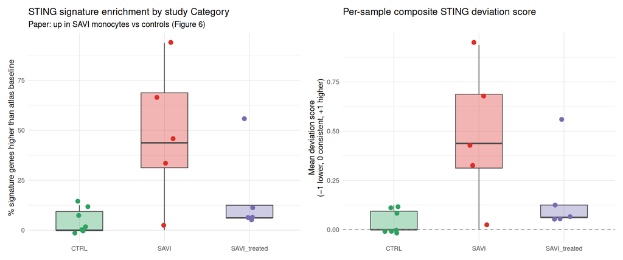

```r
category_cols <- c(
  CTRL = "#2ca25f",
  SAVI = "#de2d26",
  SAVI_treated = "#756bb1"
)

p_pct_higher <- ggplot2::ggplot(
  signature_by_sample,
  ggplot2::aes(
    x = .data$Category,
    y = .data$pct_higher,
    fill = .data$Category
  )
) +
  ggplot2::geom_boxplot(
    outlier.shape = NA,
    alpha = 0.35,
    width = 0.55,
    colour = "grey30"
  ) +
  ggplot2::geom_jitter(
    ggplot2::aes(colour = .data$Category),
    width = 0.12,
    size = 2.5,
    show.legend = FALSE
  ) +
  ggplot2::scale_fill_manual(values = category_cols) +
  ggplot2::scale_colour_manual(values = category_cols) +
  ggplot2::labs(
    x = NULL,
    y = "% signature genes higher than atlas baseline",
    title = "STING signature enrichment by study Category",
    subtitle = "Paper: up in SAVI monocytes vs controls (Figure 6)"
  ) +
  ggplot2::theme_minimal(base_size = 11) +
  ggplot2::theme(legend.position = "none")

p_signature_score <- ggplot2::ggplot(
  signature_by_sample,
  ggplot2::aes(
    x = .data$Category,
    y = .data$signature_score,
    fill = .data$Category
  )
) +
  ggplot2::geom_boxplot(
    outlier.shape = NA,
    alpha = 0.35,
    width = 0.55,
    colour = "grey30"
  ) +
  ggplot2::geom_jitter(
    ggplot2::aes(colour = .data$Category),
    width = 0.12,
    size = 2.5,
    show.legend = FALSE
  ) +
  ggplot2::geom_hline(yintercept = 0, linetype = 2, colour = "grey50") +
  ggplot2::scale_fill_manual(values = category_cols) +
  ggplot2::scale_colour_manual(values = category_cols) +
  ggplot2::labs(
    x = NULL,
    y = "Mean deviation score\n(−1 lower, 0 consistent, +1 higher)",
    title = "Per-sample composite STING deviation score"
  ) +
  ggplot2::theme_minimal(base_size = 11) +
  ggplot2::theme(legend.position = "none")

p_pct_higher / p_signature_score +
  patchwork::plot_layout(ncol = 2)
```

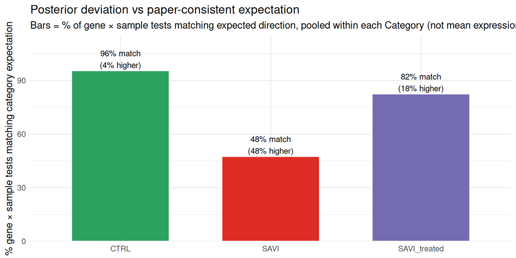

```r
ggplot2::ggplot(
  agreement_by_category,
  ggplot2::aes(
    x = .data$Category,
    y = .data$pct_match,
    fill = .data$Category
  )
) +
  ggplot2::geom_col(width = 0.65, colour = "white") +
  ggplot2::geom_text(
    ggplot2::aes(
      label = sprintf(
        "%.0f%% match\n(%.0f%% higher)",
        .data$pct_match,
        .data$pct_higher
      )
    ),
    vjust = -0.15,
    size = 3.2
  ) +
  ggplot2::scale_fill_manual(values = category_cols) +
  ggplot2::scale_y_continuous(limits = c(0, 115), expand = c(0, 0)) +
  ggplot2::labs(
    x = NULL,
    y = "% gene × sample tests matching category expectation",
    title = "Posterior deviation vs paper-consistent expectation",
    subtitle = "Bars = % of gene × sample tests matching expected direction, pooled within each Category (not mean expression)."
  ) +
  ggplot2::theme_minimal(base_size = 11) +
  ggplot2::theme(legend.position = "none")
```

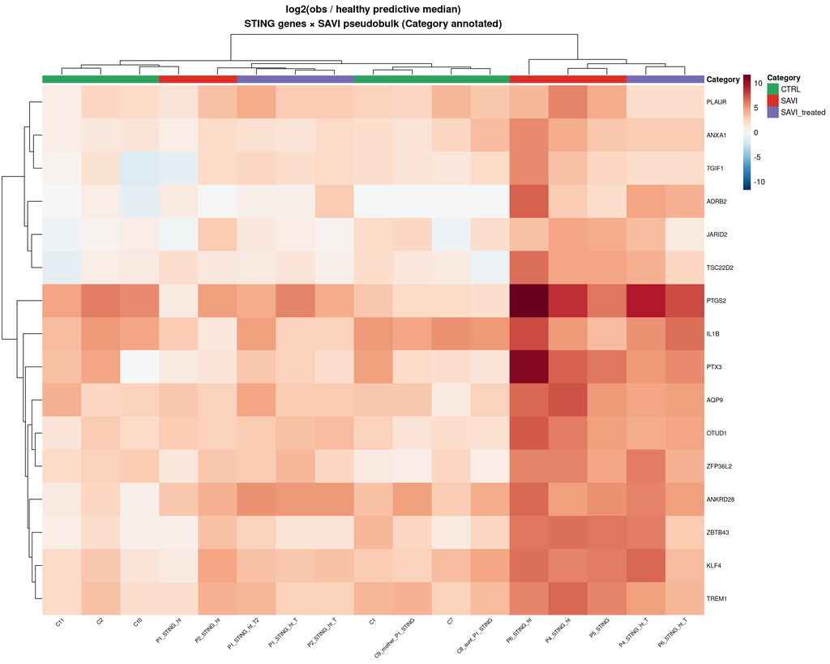

```r
heatmap_df <- gene_deviation_eval |>
  dplyr::filter(!is.na(.data$Category)) |>
  dplyr::mutate(
    Category = factor(.data$Category, levels = names(category_cols))
  )

mat_log2fc <- heatmap_df |>
  dplyr::select("gene", "sample", "log2fc_vs_median") |>
  tidyr::pivot_wider(names_from = "sample", values_from = "log2fc_vs_median") |>
  tibble::column_to_rownames("gene") |>
  as.matrix()

score_mat <- heatmap_df |>
  dplyr::select("gene", "sample", "deviation_score") |>
  tidyr::pivot_wider(names_from = "sample", values_from = "deviation_score") |>
  tibble::column_to_rownames("gene") |>
  as.matrix()

# Category only in annotation_col: pheatmap draws one legend per annotated
# column; adding Sample (~17 levels, no ann_colors) stacks a second legend and
# the "Category" title overlaps the colour keys (see pheatmap issue with multi-legends).
annotation_col <- heatmap_df |>
  dplyr::distinct(.data$sample, .data$Category) |>
  tibble::column_to_rownames("sample") |>
  dplyr::select("Category")

sample_labels <- heatmap_df |>
  dplyr::distinct(.data$sample, .data$Sample) |>
  tibble::deframe()

labels_col <- unname(sample_labels[colnames(mat_log2fc)])

ann_colors <- list(Category = category_cols)

lim_log2 <- max(abs(mat_log2fc), na.rm = TRUE)
if (!is.finite(lim_log2) || lim_log2 == 0) lim_log2 <- 1

pheatmap::pheatmap(
  mat_log2fc,
  annotation_col = annotation_col,
  annotation_colors = ann_colors,
  labels_col = labels_col,
  cluster_rows = TRUE,
  cluster_cols = TRUE,
  clustering_method = "ward.D2",
  color = grDevices::colorRampPalette(rev(RColorBrewer::brewer.pal(11, "RdBu")))(100),
  breaks = seq(-lim_log2, lim_log2, length.out = 101),
  border_color = NA,
  fontsize_row = 8,
  fontsize_col = 7,
  angle_col = 45,
  main = "log2(obs / healthy predictive median)\nSTING genes × SAVI pseudobulk (Category annotated)"
)
```

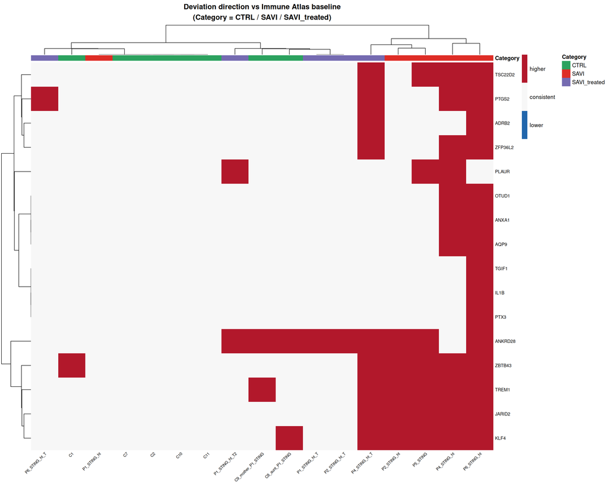

```r
pheatmap::pheatmap(
  score_mat,
  annotation_col = annotation_col,
  annotation_colors = ann_colors,
  labels_col = labels_col,
  cluster_rows = TRUE,
  cluster_cols = TRUE,
  clustering_method = "ward.D2",
  color = grDevices::colorRampPalette(c("#2166ac", "#f7f7f7", "#b2182b"))(3),
  breaks = c(-1.5, -0.5, 0.5, 1.5),
  legend_breaks = c(-1, 0, 1),
  legend_labels = c("lower", "consistent", "higher"),
  border_color = NA,
  fontsize_row = 8,
  fontsize_col = 7,
  angle_col = 45,
  main = "Deviation direction vs Immune Atlas baseline\n(Category = CTRL / SAVI / SAVI_treated)"
)
```

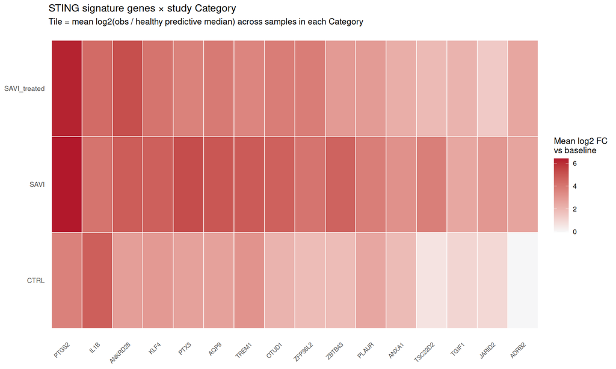

```r
gene_match_summary <- gene_deviation_eval |>
  dplyr::filter(!is.na(.data$Category)) |>
  dplyr::group_by(.data$gene, .data$Category, .data$expected_deviation) |>
  dplyr::summarise(
    n = dplyr::n(),
    pct_higher = 100 * mean(.data$signature_up),
    pct_match = 100 * mean(.data$matches_literature, na.rm = TRUE),
    mean_log2fc = mean(.data$log2fc_vs_median, na.rm = TRUE),
    .groups = "drop"
  ) |>
  dplyr::mutate(
    gene = forcats::fct_reorder(.data$gene, .data$mean_log2fc, .fun = mean, .desc = TRUE)
  )

ggplot2::ggplot(
  gene_match_summary,
  ggplot2::aes(
    x = .data$gene,
    y = .data$Category,
    fill = .data$mean_log2fc
  )
) +
  ggplot2::geom_tile(colour = "white", linewidth = 0.3) +
  ggplot2::scale_fill_gradient2(
    low = "#2166ac",
    mid = "#f7f7f7",
    high = "#b2182b",
    midpoint = 0,
    name = "Mean log2 FC\nvs baseline"
  ) +
  ggplot2::labs(
    x = NULL,
    y = NULL,
    title = "STING signature genes × study Category",
    subtitle = "Tile = mean log2(obs / healthy predictive median) across samples in each Category"
  ) +
  ggplot2::theme_minimal(base_size = 10) +
  ggplot2::theme(
    axis.text.x = ggplot2::element_text(angle = 45, hjust = 1, size = 7),
    panel.grid = ggplot2::element_blank()
  )
```

```r
gene_deviation_eval |>
  dplyr::filter(!is.na(.data$Category)) |>
  dplyr::group_by(.data$Category, .data$gene) |>
  dplyr::summarise(
    n_samples = dplyr::n_distinct(.data$sample),
    n_higher = sum(.data$signature_up),
    pct_higher = 100 * mean(.data$signature_up),
    matches_paper = all(.data$matches_literature %in% TRUE),
    .groups = "drop"
  ) |>
  dplyr::group_by(.data$Category) |>
  dplyr::summarise(
    n_genes_tested = dplyr::n(),
    n_genes_all_higher = sum(.data$n_higher == .data$n_samples),
    n_genes_majority_higher = sum(.data$pct_higher > 50),
    n_genes_paper_perfect = sum(.data$matches_paper),
    .groups = "drop"
  ) |>
  dplyr::left_join(
    agreement_by_category |>
      dplyr::select("Category", "pct_match", "pct_higher"),
    by = "Category"
  )
```

| Category | n_genes_tested | n_genes_all_higher | n_genes_majority_higher | n_genes_paper_perfect | pct_match | pct_higher |
| --- | --- | --- | --- | --- | --- | --- |
| CTRL | 16 | 0 | 0 | 12 | 95.53571 | 4.464286 |
| SAVI | 16 | 0 | 6 | 0 | 47.50000 | 47.500000 |
| SAVI_treated | 16 | 0 | 1 | 6 | 82.50000 | 17.500000 |

# Biomarker quality check (atlas-based falsification)

De Cevins *et al.* (2023) propose the **21-gene signature** by **within-cohort comparison** (5 SAVI vs 7 in-study controls). With only seven matched donors, a gene that is simply **variable in healthy people** but happened to be low in their controls can pass that filter. We can sanity-check each signature gene against a much broader **healthy reference** (Immune Atlas monocytic posteriors), which is the kind of falsification their paper could not do. The expected pattern under a true SAVI biomarker is:

- **SAVI** samples → consistently **higher** than the atlas healthy distribution
- **SAVI_treated** samples → **intermediate** (attenuated by treatment)
- **CTRL** samples → **consistent with healthy** (atlas baseline matches the in-cohort controls)

A gene fails the check (paper-supported but **not** atlas-supported) when:

- **CTRL drifts up** vs atlas (gene is high in many healthy people, not just SAVI),
- **No SAVI lift** vs CTRL (paper effect is within healthy variability),
- **SAVI_treated ≥ SAVI** (no treatment effect even though paper claims one).

```r
biomarker_per_category <- gene_deviation_eval |>
  dplyr::filter(!is.na(.data$Category)) |>
  dplyr::group_by(.data$gene, .data$Category) |>
  dplyr::summarise(
    n_samples = dplyr::n_distinct(.data$sample),
    mean_log2fc = mean(.data$log2fc_vs_median, na.rm = TRUE),
    median_log2fc = stats::median(.data$log2fc_vs_median, na.rm = TRUE),
    pct_higher = 100 * mean(.data$direction == "higher_than_healthy"),
    pct_lower = 100 * mean(.data$direction == "lower_than_healthy"),
    pct_consistent = 100 * mean(.data$direction == "consistent_with_healthy"),
    mean_p_above_healthy = mean(.data$p_above_healthy, na.rm = TRUE),
    .groups = "drop"
  )

biomarker_per_category |>
  dplyr::arrange(.data$gene, .data$Category)
```

| gene | Category | n_samples | mean_log2fc | median_log2fc | pct_higher | pct_lower | pct_consistent | mean_p_above_healthy |
| --- | --- | --- | --- | --- | --- | --- | --- | --- |
| ADRB2 | CTRL | 7 | -0.03757634 | 0.0000000 | 0.00000 | 0 | 100.00000 | 0.84811224 |
| ADRB2 | SAVI | 5 | 2.58398319 | 2.0588937 | 20.00000 | 0 | 80.00000 | 0.34678571 |
| ADRB2 | SAVI_treated | 5 | 2.54146398 | 3.0000000 | 20.00000 | 0 | 80.00000 | 0.18692857 |
| ANKRD28 | CTRL | 7 | 2.77810553 | 3.0000000 | 28.57143 | 0 | 71.42857 | 0.15520408 |
| ANKRD28 | SAVI | 5 | 4.78352259 | 4.8073549 | 60.00000 | 0 | 40.00000 | 0.03450000 |
| ANKRD28 | SAVI_treated | 5 | 5.18970215 | 5.1085245 | 80.00000 | 0 | 20.00000 | 0.01328571 |
| ANXA1 | CTRL | 7 | 1.88022354 | 1.5360529 | 0.00000 | 0 | 100.00000 | 0.19352041 |
| ANXA1 | SAVI | 5 | 3.18741197 | 3.0594043 | 40.00000 | 0 | 60.00000 | 0.10692857 |
| ANXA1 | SAVI_treated | 5 | 2.28431754 | 2.2895066 | 0.00000 | 0 | 100.00000 | 0.12821429 |
| AQP9 | CTRL | 7 | 2.68817193 | 2.5849625 | 0.00000 | 0 | 100.00000 | 0.20056122 |

[output cut: 38 more lines]

```r
biomarker_quality <- biomarker_per_category |>
  dplyr::select(
    "gene",
    "Category",
    "mean_log2fc",
    "pct_higher",
    "pct_consistent"
  ) |>
  tidyr::pivot_wider(
    names_from = "Category",
    values_from = c("mean_log2fc", "pct_higher", "pct_consistent"),
    values_fill = NA_real_,
    names_sep = "."
  ) |>
  dplyr::mutate(
    savi_lift = .data$mean_log2fc.SAVI,
    ctrl_drift = .data$mean_log2fc.CTRL,
    treated_lift = .data$mean_log2fc.SAVI_treated,

    # SAVI vs in-cohort controls' atlas-corrected position (paper's main claim).
    savi_vs_ctrl = .data$savi_lift - .data$ctrl_drift,

    # Treatment effect: positive means SAVI_treated drops back toward baseline.
    treatment_attenuation = .data$savi_lift - .data$treated_lift,

    # Atlas baseline agreement of in-study controls (closer to 0 = better).
    abs_ctrl_drift = abs(.data$ctrl_drift),

    # Composite quality: reward SAVI > CTRL, reward treatment drop,
    # penalise CTRL drift from atlas. Weights chosen so all three terms are on
    # the log2 scale; tweak if needed.
    quality_score = .data$savi_vs_ctrl +
      0.5 * .data$treatment_attenuation -
      0.5 * .data$abs_ctrl_drift,

    biomarker_class = dplyr::case_when(
      .data$pct_higher.SAVI >= 60 &
        .data$pct_consistent.CTRL >= 50 &
        .data$treatment_attenuation > 0 ~ "validated",
      .data$pct_higher.SAVI >= 60 &
        .data$treatment_attenuation > 0 &
        .data$pct_consistent.CTRL < 50 ~ "validated_ctrl_drifts",
      .data$pct_higher.SAVI >= 60 &
        .data$treatment_attenuation <= 0 ~ "savi_up_no_treatment_effect",
      .data$pct_higher.SAVI < 30 &
        .data$ctrl_drift > 0.5 ~ "falsified_baseline_high",
      .data$pct_higher.SAVI < 30 ~ "falsified_no_savi_signal",
      TRUE ~ "ambiguous"
    )
  ) |>
  dplyr::arrange(dplyr::desc(.data$quality_score))

biomarker_quality |>
  dplyr::select(
    "gene",
    "biomarker_class",
    "quality_score",
    "savi_vs_ctrl",
    "treatment_attenuation",
    "abs_ctrl_drift",
    dplyr::starts_with("pct_higher."),
    dplyr::starts_with("pct_consistent.")
  )
```

| gene | biomarker_class | quality_score | savi_vs_ctrl | treatment_attenuation | abs_ctrl_drift | pct_higher.CTRL | pct_higher.SAVI | pct_higher.SAVI_treated | pct_consistent.CTRL | pct_consistent.SAVI | pct_consistent.SAVI_treated |
| --- | --- | --- | --- | --- | --- | --- | --- | --- | --- | --- | --- |
| TSC22D2 | validated | 3.7496327 | 3.1358024 | 1.84217306 | 0.61451252 | 0.00000 | 60 | 20 | 100.00000 | 40 | 80 |
| ZBTB43 | validated | 2.6650300 | 2.7473605 | 1.68438421 | 1.84904518 | 14.28571 | 80 | 20 | 85.71429 | 20 | 80 |
| ADRB2 | falsified_no_savi_signal | 2.6240310 | 2.6215595 | 0.04251921 | 0.03757634 | 0.00000 | 20 | 20 | 100.00000 | 80 | 80 |
| JARID2 | validated | 2.3586056 | 2.0437191 | 1.58651398 | 0.95674093 | 0.00000 | 80 | 20 | 100.00000 | 20 | 80 |
| PTX3 | falsified_baseline_high | 2.0135808 | 2.5659786 | 1.57101245 | 2.67580798 | 0.00000 | 20 | 0 | 100.00000 | 80 | 100 |
| OTUD1 | ambiguous | 1.8944443 | 2.5293745 | 0.85184251 | 2.12170283 | 0.00000 | 40 | 0 | 100.00000 | 60 | 100 |
| AQP9 | ambiguous | 1.4575891 | 2.2748275 | 1.05369509 | 2.68817193 | 0.00000 | 40 | 0 | 100.00000 | 60 | 100 |
| ZFP36L2 | ambiguous | 1.4551816 | 2.2412906 | 0.26431214 | 1.83653022 | 0.00000 | 40 | 20 | 100.00000 | 60 | 80 |
| TGIF1 | falsified_baseline_high | 1.1155899 | 1.4463372 | 0.38726408 | 1.04875862 | 0.00000 | 20 | 0 | 100.00000 | 80 | 100 |
| PTGS2 | ambiguous | 0.9891115 | 2.7412099 | 0.16929291 | 3.67348970 | 0.00000 | 40 | 40 | 100.00000 | 60 | 60 |

[output cut: 6 more lines]

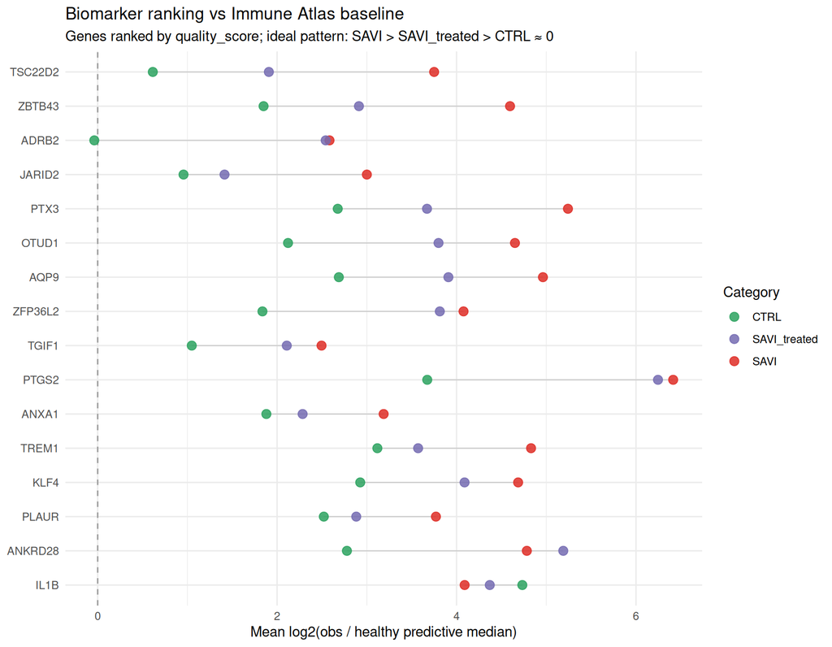

```r
gene_order <- biomarker_quality$gene

biomarker_long <- biomarker_per_category |>
  dplyr::filter(.data$gene %in% gene_order) |>
  dplyr::mutate(
    gene = factor(.data$gene, levels = rev(gene_order)),
    Category = factor(
      .data$Category,
      levels = c("CTRL", "SAVI_treated", "SAVI")
    )
  )

ggplot2::ggplot(
  biomarker_long,
  ggplot2::aes(
    x = .data$mean_log2fc,
    y = .data$gene,
    colour = .data$Category
  )
) +
  ggplot2::geom_vline(xintercept = 0, linetype = 2, colour = "grey60") +
  ggplot2::geom_line(
    ggplot2::aes(group = .data$gene),
    colour = "grey80",
    linewidth = 0.4
  ) +
  ggplot2::geom_point(size = 3, alpha = 0.85) +
  ggplot2::scale_colour_manual(values = category_cols) +
  ggplot2::labs(
    x = "Mean log2(obs / healthy predictive median)",
    y = NULL,
    title = "Biomarker ranking vs Immune Atlas baseline",
    subtitle = "Genes ranked by quality_score; ideal pattern: SAVI > SAVI_treated > CTRL ≈ 0"
  ) +
  ggplot2::theme_minimal(base_size = 11)
```

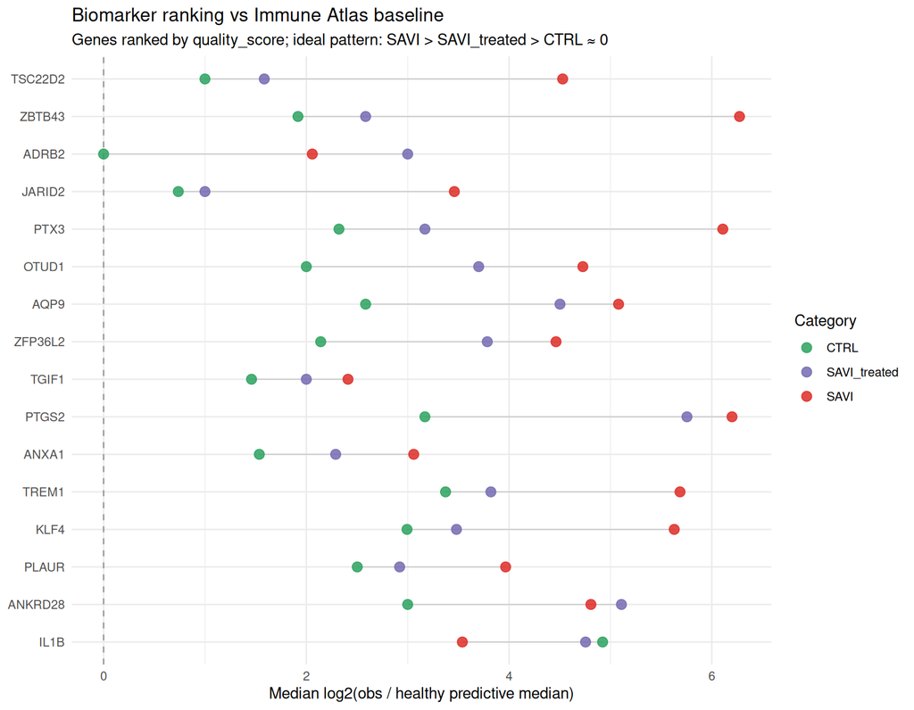

```r
ggplot2::ggplot(
  biomarker_long,
  ggplot2::aes(
    x = .data$median_log2fc,
    y = .data$gene,
    colour = .data$Category
  )
) +
  ggplot2::geom_vline(xintercept = 0, linetype = 2, colour = "grey60") +
  ggplot2::geom_line(
    ggplot2::aes(group = .data$gene),
    colour = "grey80",
    linewidth = 0.4
  ) +
  ggplot2::geom_point(size = 3, alpha = 0.85) +
  ggplot2::scale_colour_manual(values = category_cols) +
  ggplot2::labs(
    x = "Median log2(obs / healthy predictive median)",
    y = NULL,
    title = "Biomarker ranking vs Immune Atlas baseline",
    subtitle = "Genes ranked by quality_score; ideal pattern: SAVI > SAVI_treated > CTRL ≈ 0"
  ) +
  ggplot2::theme_minimal(base_size = 11)
```

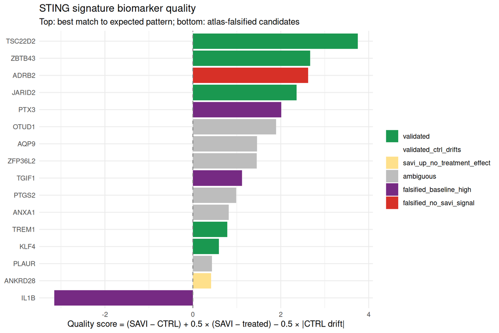

```r
class_levels <- c(
  "validated",
  "validated_ctrl_drifts",
  "savi_up_no_treatment_effect",
  "ambiguous",
  "falsified_baseline_high",
  "falsified_no_savi_signal"
)

class_cols <- c(
  validated = "#1a9850",
  validated_ctrl_drifts = "#66bd63",
  savi_up_no_treatment_effect = "#fee08b",
  ambiguous = "#bdbdbd",
  falsified_baseline_high = "#762a83",
  falsified_no_savi_signal = "#d73027"
)

ggplot2::ggplot(
  biomarker_quality |>
    dplyr::mutate(
      gene = factor(.data$gene, levels = rev(gene_order)),
      biomarker_class = factor(
        .data$biomarker_class,
        levels = class_levels
      )
    ),
  ggplot2::aes(
    x = .data$quality_score,
    y = .data$gene,
    fill = .data$biomarker_class
  )
) +
  ggplot2::geom_col() +
  ggplot2::geom_vline(xintercept = 0, linetype = 2, colour = "grey50") +
  ggplot2::scale_fill_manual(values = class_cols, drop = FALSE) +
  ggplot2::labs(
    x = "Quality score = (SAVI − CTRL) + 0.5 × (SAVI − treated) − 0.5 × |CTRL drift|",
    y = NULL,
    title = "STING signature biomarker quality",
    subtitle = "Top: best match to expected pattern; bottom: atlas-falsified candidates",
    fill = NULL
  ) +
  ggplot2::theme_minimal(base_size = 11) +
  ggplot2::theme(legend.position = "right")
```

```r
biomarker_quality |>
  dplyr::count(.data$biomarker_class, name = "n_genes") |>
  dplyr::arrange(dplyr::desc(.data$n_genes))
```

| biomarker_class | n_genes |
| --- | --- |
| ambiguous | 6 |
| validated | 5 |
| falsified_baseline_high | 3 |
| falsified_no_savi_signal | 1 |
| savi_up_no_treatment_effect | 1 |

```r
biomarker_quality |>
  dplyr::filter(.data$biomarker_class %in% c(
    "falsified_no_savi_signal",
    "falsified_baseline_high",
    "savi_up_no_treatment_effect"
  )) |>
  dplyr::select(
    "gene",
    "biomarker_class",
    "savi_lift",
    "ctrl_drift",
    "treated_lift",
    "pct_higher.SAVI",
    "pct_higher.CTRL",
    "pct_consistent.CTRL"
  ) |>
  dplyr::arrange(.data$biomarker_class, .data$gene)
```

| gene | biomarker_class | savi_lift | ctrl_drift | treated_lift | pct_higher.SAVI | pct_higher.CTRL | pct_consistent.CTRL |
| --- | --- | --- | --- | --- | --- | --- | --- |
| IL1B | falsified_baseline_high | 4.090247 | 4.73331023 | 4.370370 | 20 | 0.00000 | 100.00000 |
| PTX3 | falsified_baseline_high | 5.241787 | 2.67580798 | 3.670774 | 20 | 0.00000 | 100.00000 |
| TGIF1 | falsified_baseline_high | 2.495096 | 1.04875862 | 2.107832 | 20 | 0.00000 | 100.00000 |
| ADRB2 | falsified_no_savi_signal | 2.583983 | -0.03757634 | 2.541464 | 20 | 0.00000 | 100.00000 |
| ANKRD28 | savi_up_no_treatment_effect | 4.783523 | 2.77810553 | 5.189702 | 60 | 28.57143 | 71.42857 |

**Interpretation:**

- **`validated`** — gene behaves as the paper claims and is **also** consistent with the atlas (high in SAVI, attenuated by treatment, in-cohort controls match atlas baseline). Strong biomarker.
- **`validated_ctrl_drifts`** — gene goes up in SAVI and drops with treatment, but the paper’s controls are already above the atlas baseline. The within-cohort effect is real; absolute reference value should be interpreted with care.
- **`savi_up_no_treatment_effect`** — SAVI lift exists but treatment doesn’t move it. The gene may be a state marker rather than an activity readout.
- **`ambiguous`** — borderline; needs more samples.
- **`falsified_baseline_high`** — gene reads as high in study controls *and* in the broader atlas, and SAVI doesn’t add much on top. The paper’s “up in SAVI” is likely a baseline artefact.
- **`falsified_no_savi_signal`** — no SAVI lift vs atlas at all. Strong falsification candidate.

This is the kind of cross-study check the original paper could not perform because of the small healthy-cohort size.